# 上一篇博客中说道，不同的缩并顺序有可能影响到计算的复杂度

比如在以下示例中，先缩并ab两个张量还是先缩并bc两个张量，最终得到的计算复杂度的结果是不一样的。

```python
import numpy as np
np.random.seed(123)
a = np.random.rand(2, 2)
b = np.random.rand(2, 5)
c = np.random.rand(5, 2)
path_info = np.einsum_path('ij,jk,kl->il', a, b, c, optimize='greedy')
print(path_info[0])
print(path_info[1])
```

```
['einsum_path', (1, 2), (0, 1)]
  Complete contraction:  ij,jk,kl->il
         Naive scaling:  4
     Optimized scaling:  3
      Naive FLOP count:  1.200e+02
  Optimized FLOP count:  5.700e+01
   Theoretical speedup:  2.105
  Largest intermediate:  4.000e+00 elements
--------------------------------------------------------------------------
scaling                  current                                remaining
--------------------------------------------------------------------------
   3                   kl,jk->jl                                ij,jl->il
   3                   jl,ij->il                                   il->il
```

# 这里我们直接测试一下两种顺序对应的运行时间

从这里的数据中我们其实无法直接判断出来缩并顺序对运行时间的影响，只能大致看出复杂度较低的场景计算时间确实更低一些，因为误差在$0.1\mu s$的级别，让我们继续测试规模较大的张量缩并。

```python
import numpy as np
def order1():
    a = np.random.rand(2, 2)
    b = np.random.rand(2, 5)
    c = np.random.rand(5, 2)
    d = np.dot(a,b)
    e = np.dot(d,c)
    return e
print ('The result for order1:\n{}'.format(order1()))
def order2():
    a = np.random.rand(2, 2)
    b = np.random.rand(2, 5)
    c = np.random.rand(5, 2)
    d = np.dot(b,c)
    e = np.dot(a,d)
    return e
print ('The result for order2:\n{}'.format(order2()))
```

```
The result for order1:
[[2.35400244 1.1372466 ]
 [1.50006633 0.7931948 ]]
The result for order2:
[[1.63458122 2.37671021]
 [1.17874868 1.48566535]]
```

```python
%timeit order1()
%timeit order2()
```

```
3.58 µs ± 44.2 ns per loop (mean ± std. dev. of 7 runs, 100000 loops each)
3.56 µs ± 20.9 ns per loop (mean ± std. dev. of 7 runs, 100000 loops each)
```

# 这个示例也在上一篇博客中提到，我们这里可以用networkx把图展示出来

注意这里图中的v1和v2两个点，仅仅用于展示ab两点的dangling边，该边不一定需要连接其他的节点。从这个示例中，我们可以看出运行时间有较为明显的差别，但是这个差距我们还是可以接受的，是否有差距更加明显的地方呢？

```python
import numpy as np
np.random.seed(123)
a = np.random.rand(2, 2, 2)
b = np.random.rand(2, 2, 2, 2)
c = np.random.rand(2, 2, 2)
d = np.random.rand(2, 2)
path_info = np.einsum_path('ijk,jlmn,klo,mo->in', a, b, c, d, optimize='greedy')
print(path_info[0])
print(path_info[1])
```

```
['einsum_path', (2, 3), (1, 2), (0, 1)]
  Complete contraction:  ijk,jlmn,klo,mo->in
         Naive scaling:  7
     Optimized scaling:  5
      Naive FLOP count:  5.120e+02
  Optimized FLOP count:  1.290e+02
   Theoretical speedup:  3.969
  Largest intermediate:  8.000e+00 elements
--------------------------------------------------------------------------
scaling                  current                                remaining
--------------------------------------------------------------------------
   4                 mo,klo->klm                         ijk,jlmn,klm->in
   5               klm,jlmn->jkn                              ijk,jkn->in
   4                 jkn,ijk->in                                   in->in
```

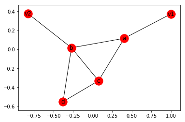

```python
import networkx as nx
graph = nx.Graph()
graph.add_nodes_from(['a','b','c','d','v1','v2'])
graph.add_edges_from([('a','b'), ('a','c'), ('b','c'), ('b','d'), ('c','d'), ('a','v1'), ('b','v2')])
nx.draw_networkx(graph)
```

```python
import numpy as np
def order1():
    a = np.random.rand(2, 2, 2)
    b = np.random.rand(2, 2, 2, 2)
    c = np.random.rand(2, 2, 2)
    d = np.random.rand(2, 2)
    b = np.dot(b,c)
    b = np.dot(b,d)
    a = np.dot(a,b)
    return a
def order2():
    a = np.random.rand(2, 2, 2)
    b = np.random.rand(2, 2, 2, 2)
    c = np.random.rand(2, 2, 2)
    d = np.random.rand(2, 2)
    c = np.dot(c,d)
    b = np.dot(b,c)
    a = np.dot(a,b)
    return a
```

```python
%timeit order1()
%timeit order2()
```

```
8.79 µs ± 213 ns per loop (mean ± std. dev. of 7 runs, 100000 loops each)
8.02 µs ± 45.4 ns per loop (mean ± std. dev. of 7 runs, 100000 loops each)
```

```python
import numpy as np
def order1():
    a = np.random.rand(2000, 2000)
    b = np.random.rand(2000, 5000)
    c = np.random.rand(5000, 2000)
    d = np.dot(a,b)
    e = np.dot(d,c)
    return e
def order2():
    a = np.random.rand(2000, 2000)
    b = np.random.rand(2000, 5000)
    c = np.random.rand(5000, 2000)
    d = np.dot(b,c)
    e = np.dot(a,d)
    return e
```

```python
%timeit order1()
%timeit order2()
```

```
848 ms ± 16.2 ms per loop (mean ± std. dev. of 7 runs, 1 loop each)
650 ms ± 7.55 ms per loop (mean ± std. dev. of 7 runs, 1 loop each)
```

```python
import numpy as np
dd = 20
def order1():
    global dd
    a = np.random.rand(dd, dd, dd)
    b = np.random.rand(dd, dd, dd, dd)
    c = np.random.rand(dd, dd, dd)
    d = np.random.rand(dd, dd)
    b = np.dot(b,c)
    b = np.dot(b,d)
    a = np.dot(a,b)
    return a
def order2():
    global dd
    a = np.random.rand(dd, dd, dd)
    b = np.random.rand(dd, dd, dd, dd)
    c = np.random.rand(dd, dd, dd)
    d = np.random.rand(dd, dd)
    c = np.dot(c,d)
    b = np.dot(b,c)
    a = np.dot(a,b)
    return a
```

```python
%timeit order1()
%timeit order2()
```

```
4.27 s ± 42.9 ms per loop (mean ± std. dev. of 7 runs, 1 loop each)
4.13 s ± 38.9 ms per loop (mean ± std. dev. of 7 runs, 1 loop each)
```

# 总结